# noaaVPI

Ian Combs – icombs@mote.org

### version: April 09, 2024

#### [GitHub repository](https://github.com/icombs2017/photogrammetryNOAA.git)

This is the analysis pipeline for data generated from TagLab annotations of our 6 10x10m plots.

### All analyses performed with R verion 4.3.1

# Basic setup of R environment

## Loading required packages

For the following analyses we will require the use of a number of different R packages. Most of which can be sourced from CRAN, but some must be downloaded from GitHub. We can use the following code to load in the packages and install any packages not previously installed in the R console.

```r
if (!require("pacman")) install.packages("pacman")
pacman::p_load("ggplot2", "officer", "ggpubr", "rcompanion", "RColorBrewer", "patchwork", "magrittr", "reshape2", "stringr", "plyr", "dplyr", "flextable", "tidyr", "tibble", "vegan", "forcats", "readr", "metafolio", "FSA", "viridis", "paletteer", 'tidyverse', "ecodist", "glue")
pacman::p_load_gh("pmartinezarbizu/pairwiseAdonis/pairwiseAdonis")
```

# Loading Data

Data is exported from Viscore’s VPI scriplet as a .csv file and named according to the file. We have multiple .csv’s that we wish to compile so we created a function called `read_plus` that will read all the .csv’s into one data frame witht he file name as a column. We will then parse out various pieces of the file name to provide us use ful columns e.g. date, site, etc. Since Viscore puts the “percent” column as a percentage sign (**%**) R cannot read it in we are using `dplyr`’s `rename` function to change it to something R can read and that is easier to call and read when we are handling the data. I am also adding **site** and **time** columns to each subset, combining all subsets into one large dataframe using `bind_rows()`, adding a **treatment** column and using the `gsub()` to rename some.

```r
read_plus <- function(flnm) {
    read_csv(flnm) %>%
        mutate(filename = flnm)
}

vpiData1 <-
    list.files(path = "../data/vpi", pattern = "*.csv",
               full.names = T) %>%
    map_df(~read_plus(.))


# Sort out data to have proper columns for all the info i want e.g. site, date etc

vpiData <- vpiData1 %>%
      tidyr::separate(filename, into=c("Date", "Site"),extra = 'merge',sep = 23) %>%
      tidyr::separate(Date, into=c("remove", "Date"),sep = "../data/vpi/") %>%
      tidyr::separate(Date, into=c("Date", "remove"),sep = 10) %>%
      tidyr::separate(Site, into = c("Site", "delete"),sep = 5) %>%
      dplyr::select(-c(remove, delete)) %>%
      mutate_if(is.character, str_replace_all, pattern = "_", replacement = "-") %>%
      dplyr::rename(abundance = `%`) %>%
      tidyr::drop_na(abundance) %>%
      mutate(Date = factor(Date), Site = factor(Site), timePoint = factor(timePoint), year = factor(year))

#Making some corrections in the naming

vpiData <- vpiData %>%
  mutate_all(~gsub("Crustose coralline algae natans", "Crustose coralline algae", .)) %>%
  mutate_all(~gsub("Cordata", "Chordata", .)) %>%
  mutate_all(~gsub("Rubble", "Bare Substrate", .)) %>%
  mutate_all(~gsub("Other|Review|None", NA, .))


vpiData<- na.omit(vpiData)
vpiData$class <- as.factor(vpiData$class)

vpiData$class <-  droplevels.factor(vpiData$class)

vpiData$treatment = if_else(vpiData$Site %in% c("IC-C2", "IC-Z1", "IC-U1"), "Control","Outplanted")
vpiData$reef = if_else(vpiData$Site %in% c("IC-C1", "IC-C2", "IC-C3"), "SiteC",
                   if_else(vpiData$Site %in% c("IC-U1", "IC-U2", "IC-U3"), "SiteU", "SiteZ"))
vpiData$reef <- as.factor(vpiData$reef)

vpiData <- vpiData %>%
      select(Date, timePoint, year, Site, treatment, reef, class, count, abundance) %>%
      mutate(Date = as.Date(Date)) %>%
    mutate(count = as.numeric(count), abundance = as.numeric(abundance)) %>%
  mutate(across(where(is.character), factor))



head(vpiData)
```

```
## # A tibble: 6 × 9
##   Date       timePoint year  Site  treatment  reef  class        count abundance
##   <date>     <fct>     <fct> <fct> <fct>      <fct> <fct>        <dbl>     <dbl>
## 1 2020-08-18 T0        Y1    IC-C1 Outplanted SiteC Porites ast…     3    0.120
## 2 2020-08-18 T0        Y1    IC-C1 Outplanted SiteC Siderastrea…    21    0.840
## 3 2020-08-18 T0        Y1    IC-C1 Outplanted SiteC Stephanocoe…     7    0.280
## 4 2020-08-18 T0        Y1    IC-C1 Outplanted SiteC Colpophylli…     1    0.0400
## 5 2020-08-18 T0        Y1    IC-C1 Outplanted SiteC Diploria la…     1    0.0400
## 6 2020-08-18 T0        Y1    IC-C1 Outplanted SiteC Octocorallia    80    3.20
```

Going from long to wide format (matrix) and also creating a separate dataframe with just the samples metadata.

```r
vpiMat <- vpiData %>%
  select(-c(abundance)) %>%
  tidyr::unite(sample, 1:6) %>%
  spread(class,count) %>%
  replace(is.na(.), 0) %>%
  # mutate_at(c('sample'), as.character) %>%
  column_to_rownames(var = 'sample')

dist_matrix <- as.matrix(bcdist(vpiMat),byrow = TRUE)


dist_tbl <- dist_matrix %>%
        as_tibble(rownames = 'samples')

samples <- dist_tbl %>%
  select(samples)


 samples_lookup <- dist_tbl %>%
   select(samples) %>%
   separate(col = samples, into = c("date", "timePoint", "year", "site", "treatment", "reef"), sep = "_", remove = FALSE)





dist_tbl %>%
  pivot_longer(cols = -samples, names_to = "b", values_to = "distances") %>%
  pivot_wider(names_from = "b", values_from = "distances")
```

```
## # A tibble: 24 × 25
##    samples  2020-08-18_T0_Y1_IC-…¹ 2020-08-18_T0_Y1_IC-…² 2020-08-18_T0_Y1_IC-…³
##    <chr>                     <dbl>                  <dbl>                  <dbl>
##  1 2020-08…                 0                      0.0403                  0.325
##  2 2020-08…                 0.0403                 0                       0.364
##  3 2020-08…                 0.325                  0.364                   0
##  4 2020-08…                 0.217                  0.248                   0.125
##  5 2020-08…                 0.218                  0.256                   0.109
##  6 2020-08…                 0.0278                 0.0656                  0.298
##  7 2021-06…                 0.0280                 0.0479                  0.320
##  8 2021-06…                 0.0702                 0.0900                  0.281
##  9 2021-06…                 0.222                  0.247                   0.125
## 10 2021-06…                 0.106                  0.131                   0.258
## # ℹ 14 more rows
## # ℹ abbreviated names: ¹`2020-08-18_T0_Y1_IC-C1_Outplanted_SiteC`,
## #   ²`2020-08-18_T0_Y1_IC-C2_Control_SiteC`,
## #   ³`2020-08-18_T0_Y1_IC-Z1_Control_SiteZ`
## # ℹ 21 more variables: `2020-08-18_T0_Y1_IC-Z2_Outplanted_SiteZ` <dbl>,
## #   `2020-08-19_T0_Y1_IC-U1_Control_SiteU` <dbl>,
## #   `2020-08-19_T0_Y1_IC-U2_Outplanted_SiteU` <dbl>, …
```

```r
dist_matrix <- dist_tbl %>%
  pivot_longer(cols=-samples, names_to="b", values_to="distances") %>%
  inner_join(., samples_lookup, by="samples") %>%
  inner_join(., samples_lookup, by=c("b" = "samples")) %>%
  # filter(day.x %in% days_wanted & day.y %in% days_wanted) %>%
  select(samples, b, distances) %>%
  pivot_wider(names_from="b", values_from="distances") %>%
  select(-samples) %>%
  as.dist()
```

Creating a PCoA using a distance matrix using curtis-bray distances

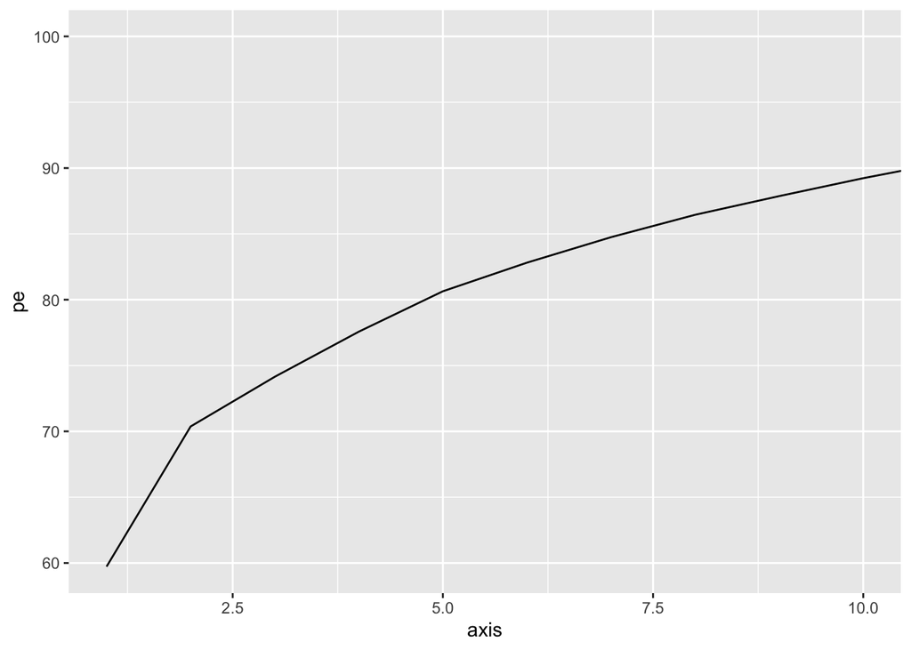

```r
pcoa <- cmdscale(dist_matrix, k = 2, eig = TRUE, add = TRUE) # add k = 3, k = 5 to add columns, default is k=2
positions <- pcoa$points
colnames(positions) <- c("pcoa1", 'pcoa2')
# calculating the amount of variation explained by each dimension
percentExplained <- 100 * (pcoa$eig / sum(pcoa$eig))

#rounding and trimming to add to labels
RoundPercentExplained <- format(round(percentExplained[1:2], digits = 1), nsmall = 1, trim = TRUE)

# creating label vector
labs <- c(glue("PCo 1 ({RoundPercentExplained[1]}%)"),
          glue("PCo 2 ({RoundPercentExplained[2]}%)"))



treatmentCentroid <- positions %>% as_tibble(rownames='samples') %>%
  inner_join(., samples_lookup, by = 'samples') %>%
  group_by(treatment) %>%
  dplyr::summarise(axis1 = mean(pcoa1),
            axis2 = mean(pcoa2))



#
pcoaTbl <- positions %>% as_tibble(rownames='samples') %>%
  inner_join(., samples_lookup, by = 'samples')

pcoaPlot1 <- ggplot() +
  geom_point(data = pcoaTbl, mapping = aes(x = pcoa1, y = pcoa2, color = treatment, shape = timePoint), size = 3) +
  geom_point(data = treatmentCentroid, mapping = aes(x = axis1, y = axis2, color = treatment), shape = 15, size = 5) +
  labs(x = labs[1], y = labs[2])


pcoaPlot2 <- ggplot(pcoaTbl, aes(x = pcoa1, y = pcoa2, color = treatment, fill = treatment)) +
  stat_ellipse(geom = 'polygon', alpha = 0.2, level = 0.75, show.legend = FALSE) +
  geom_point(aes(x = pcoa1, y = pcoa2, shape = year), alpha = 1, size = 3) +
  ggtitle("Principle Coordinate Analysis of VPI Data")+
  labs(x = labs[1], y = labs[2])

pcoaPlot <- pcoaPlot2 + theme(
    # Title
    plot.title = element_text(size = 40, face = "bold"),
    # X Axis
    axis.text.x = element_text(angle = 45, hjust = 1),
    axis.title.x = element_text(size = 20, face = "bold"),
    # Y Axis
    axis.title.y = element_text(size = 20, face = "bold"),
    axis.text.y = element_text(colour = "black", size = 20, face = "bold"),
    # Axis Lines and Ticks
    axis.line = element_line(colour = "black"),
    axis.ticks = element_line(color="black"),
    # Legend
    legend.title = element_text(size = 20, face = "bold"),
    legend.text = element_text(size = 20, face = "bold", colour = "black"),
    legend.position = "bottom",
    # Grid and Background
    panel.grid.major = element_line(size = 0.3, linetype = 'solid', colour = "black"),
    panel.background = element_rect(fill = 'white'),
    # Text
    text = element_text(size=20, color="black"))

ggsave("../figures/pcoa.png", plot = pcoaPlot, width = 20, height = 15, units = 'in', dpi = 600)





tibble(pe = cumsum(percentExplained),
       axis = 1:length(percentExplained)) %>%
  ggplot(aes(x = axis, y = pe))+
  geom_line()+
  coord_cartesian(xlim = c(1,10))
```

Creating an NMDS using that same distance matrix

```r
set.seed(3008)
nmds <- metaMDS(dist_matrix)
```

```
## *** Best solution repeated 1 times
```

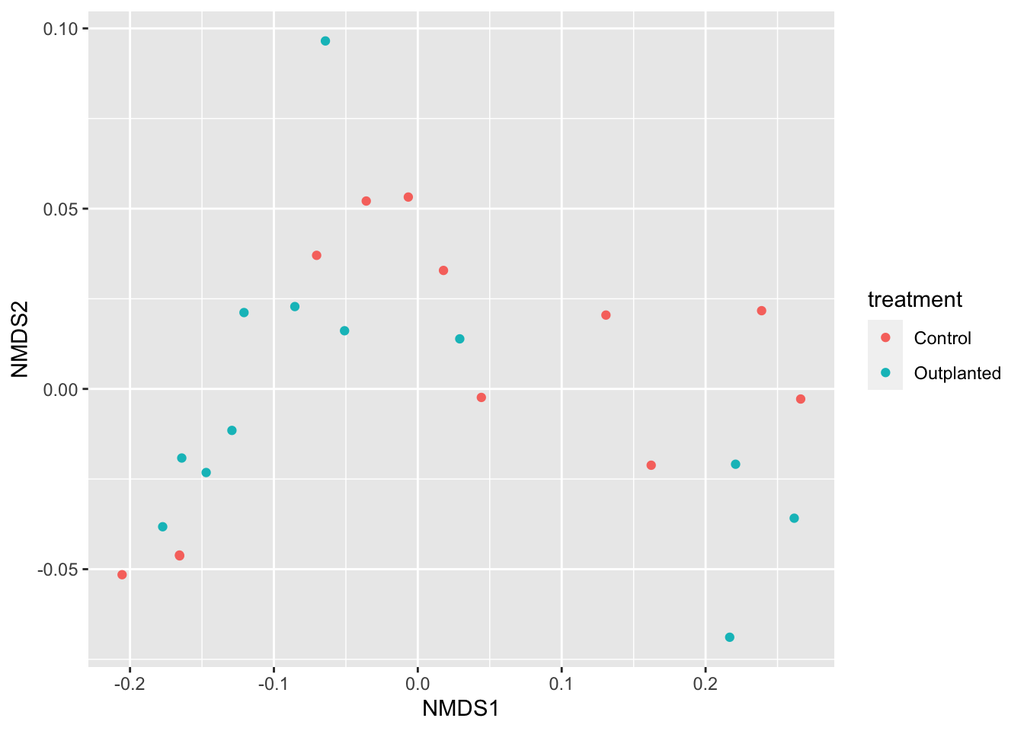

```r
scores(nmds) %>%
  as_tibble(rownames='samples') %>%
  inner_join(., samples_lookup, by = 'samples') %>%
  ggplot(aes(x = NMDS1, y = NMDS2, color = treatment))+
  geom_point()
```

```r
ecoMat <- as.matrix(vpiMat)
samples_lookup <- vpiMat %>%
  rownames_to_column(var = 'samples') %>%
   select(samples) %>%
   separate(col = samples, into = c("date", "timePoint", "year", "site", "treatment", "reef"), sep = "_", remove = FALSE)


set.seed(3008)
dist <- vegdist(ecoMat, method = 'bray')
nmds <- metaMDS(dist)
```

```
## *** Best solution repeated 1 times
```

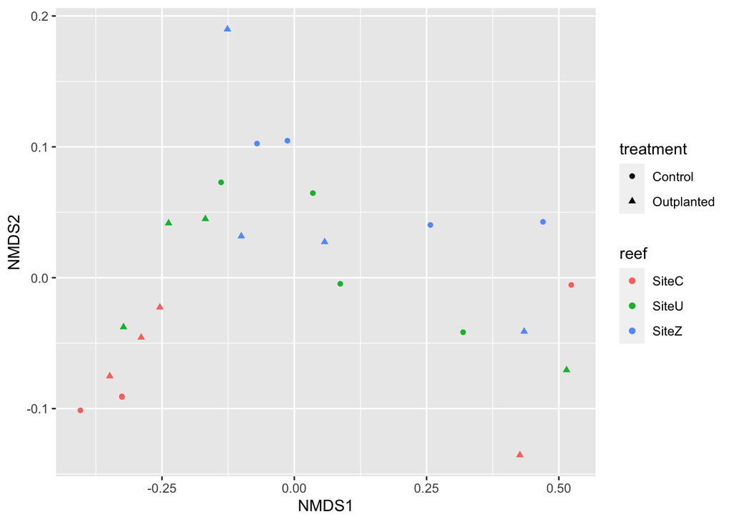

```r
scores(nmds) %>%
  as_tibble(rownames = 'samples') %>%
  inner_join(., samples_lookup, by = 'samples') %>%
  ggplot(aes(x = NMDS1, y = NMDS2, shape = treatment, color = reef))+
  geom_point()
```

# PERMANOVA

Running a PERMANOVA since the data does not meet the assumptions of normality. We are running the PERMANOVA on the dissimilarity matrix we created above but we are running it by removing Bare Substrate from our matrix.

```r
# doing PERMANOVA on a dissimilarity matrix, 'old' code is commented below.

set.seed(9999)

vpiMat1 <- vpiMat %>%
  select(-c(`Bare Substrate`))



 samplesLookupPerm <- vpiMat1 %>%
   rownames_to_column(var = "samples") %>%
   select(samples) %>%
   separate(col = samples, into = c("date", "timePoint", "year", "site", "treatment", "reef"), sep = "_", remove = FALSE) %>%
   column_to_rownames(var = "samples")

vpiDist <- vegdist(vpiMat1, method = 'bray')

distPerm <- adonis2(vpiDist ~ treatment*year*timePoint, data = samplesLookupPerm, permutations = 9999, method = 'bray')

distPerm
```

```
## Permutation test for adonis under reduced model
## Terms added sequentially (first to last)
## Permutation: free
## Number of permutations: 9999
##
## adonis2(formula = vpiDist ~ treatment * year * timePoint, data = samplesLookupPerm, permutations = 9999, method = "bray")
##                          Df SumOfSqs      R2       F Pr(>F)
## treatment                 1  0.01194 0.01134  0.6308 0.5160
## year                      1  0.32433 0.30800 17.1407 0.0006 ***
## timePoint                 1  0.18153 0.17239  9.5940 0.0024 **
## treatment:year            1  0.01508 0.01432  0.7969 0.4278
## treatment:timePoint       1  0.00701 0.00666  0.3706 0.6855
## year:timePoint            1  0.20398 0.19371 10.7801 0.0019 **
## treatment:year:timePoint  1  0.00640 0.00608  0.3385 0.7121
## Residual                 16  0.30275 0.28750
## Total                    23  1.05302 1.00000
## ---
## Signif. codes:  0 '***' 0.001 '**' 0.01 '*' 0.05 '.' 0.1 ' ' 1
```

# Output Table ***

Creating a publication-ready table from the output of our PERMANOVA above. This is mainly using the package `flextable`.

```r
distPermTab <- distPerm %>%
  as_tibble(rownames = "Comparison") %>%
  rename(`Pseudo.F` = `F`, `p.value` = `Pr(>F)`) %>%
  select(Comparison, Df, `Pseudo.F`, `p.value`) %>%
  mutate_if(is.numeric, round, digits = 3) %>%
    mutate(p.value = replace(p.value, p.value >= 0.05, "ns")) %>%
  mutate(p.value = replace(p.value, p.value < 0.001, "< 0.001")) %>%
  mutate_if(is.character, str_replace_all, pattern = "-", replacement = "–") %>%
  flextable() %>%
  set_header_labels(Data.set = "Data set") %>%
  flextable::compose(part = "header", j = "Df", value = as_paragraph("Df")) %>%
  flextable::compose(part = "header", j = "Pseudo.F", value = as_paragraph("Pseudo-F")) %>%
  flextable::compose(part = "header", j = "p.value", value = as_paragraph(as_i("p"), "-value")) %>%
  autofit() %>%
  font(fontname = "Times New Roman", part = "all") %>%
  fontsize(size = 12, part = "all") %>%
  bold(part = "header") %>%
  colformat_num(j = 'Df', digits = 2) %>%
  colformat_num(j = "Pseudo.F", digits = 2) %>%
  colformat_num(j = "p.value", digits = 4, na_str = "ns") %>%
  align_nottext_col(align = "center", header = TRUE, footer = TRUE) %>%
  align(align = "center", j = "p.value")

distDoc = read_docx()
distDoc = body_add_flextable(distDoc, value = distPermTab)
print(distDoc, target = "../tables/distTableVpi.docx")
distPermTab
```

| Comparison | Df | Pseudo-F | p-value |
| --- | --- | --- | --- |
| treatment | 1 | 0.631 | ns |
| year | 1 | 17.141 | 0.001 |
| timePoint | 1 | 9.594 | 0.002 |
| treatment:year | 1 | 0.797 | ns |
| treatment:timePoint | 1 | 0.371 | ns |
| year:timePoint | 1 | 10.780 | 0.002 |
| treatment:year:timePoint | 1 | 0.338 | ns |
| Residual | 16 |  |  |
| Total | 23 |  |  |

# Plotting the data

```r
myColors <- brewer.pal(n = 10, name = "RdBu")

boxPlotData <- vpiMat1 %>%
   rownames_to_column(var = "samples") %>%
    separate(col = samples, into = c("date", "timePoint", "year", "site", "treatment", "reef"), sep = "_", remove = FALSE) %>%
  select(-c(samples)) %>%
  gather(class, count, 7:32, factor_key = TRUE) %>%
  as_tibble() %>%
  mutate_at(c("date", "timePoint", "year", "site", "treatment", "reef", "class"), as.factor) %>%
  group_by(timePoint, reef, site, treatment, class) %>%
  summarise(sumCount = sum(count)) %>%
  arrange(desc(sumCount)) %>%
  group_by(timePoint, reef, site, treatment) %>%
  mutate(totalObservations = sum(sumCount)) %>%
  group_by(timePoint, reef, site, treatment, class) %>%
  mutate(abundance = (sumCount/totalObservations)*100) %>%
  filter(abundance > 1) %>%
  arrange(desc(abundance)) %>%
  droplevels() %>%
  mutate(class = factor(class, unique(class)))



vpiStack1 <- ggplot(boxPlotData, aes(x = timePoint, y = abundance)) +
                      geom_bar(aes(fill = class), position = position_stack(), stat = 'identity', color = 'black', alpha = 0.8) +
                      ylim(0,100) +
                      labs(y = "Relative Abundance (%)", fill = "Class", title = "Relative Species Abundance > 1%")+
                      scale_fill_manual(values = myColors)+
                      facet_wrap(treatment ~ site, scales = 'free')




vpiStack <- vpiStack1+theme(
    # Title
    plot.title = element_text(size = 40, face = "bold"),
    # X Axis
    axis.text.x = element_text(size = 40, colour = "black", vjust = 0.5, hjust = 0.5, face= "bold"),
    axis.title.x = element_blank(),
    # Y Axis
    axis.title.y = element_text(size = 40, face = "bold"),
    axis.text.y = element_text(colour = "black", size = 40, face = "bold"),
    # Axis Lines and Ticks
    axis.line = element_line(colour = "black"),
    axis.ticks = element_line(color="black"),
    # Legend
    legend.title = element_text(size = 40, face = "bold"),
    legend.text = element_text(size = 36, face = "bold", colour = "black"),
    legend.position = "right",
    # Grid and Background
    panel.grid.major = element_line(size = 0.5, linetype = 'solid', colour = "black"),
    panel.background = element_rect(fill = '#D3D3D3'),
    # Text
    text = element_text(size=40, color="black"),
    #rectangle
    rect = element_rect(fill = "transparent"))






vpiStack





ggsave("../figures/vpiStack.png", plot = vpiStack, width = 40, height = 20, units = 'in', dpi = 600)
```

[output not shown]

# Coral Evenness, Richness, and coral cover

```r
# Aggregate abundance by treatment and timePoint using dplyr
treatment_time_abundance <- vpiData %>%
  select(1:8) %>%
  filter(!class %in% c("Bare Substrate"))

# Calculate species richness
richness <- treatment_time_abundance %>%
  group_by(treatment, year, timePoint, reef, Site) %>%
  summarise(richness = specnumber(count))
```

```
## You can override using the `.groups` argument.
```

```r
richnessMat <- richness %>%
  tidyr::unite(sample, 1:4) %>%
  spread(Site, richness, fill = 0) %>%
  column_to_rownames(var = 'sample')

samplesLookupPerm <- richnessMat %>%
   rownames_to_column(var = "samples") %>%
   select(samples) %>%
   separate(col = samples, into = c("treatment", "year", "timePoint", "Reef"), sep = "_", remove = FALSE) %>%
   column_to_rownames(var = "samples")


richnessDist <- vegdist(richnessMat, method = 'jaccard')

# Perform PERMANOVA
richnessPerm <- adonis2(richnessDist ~ treatment*timePoint*year, data = samplesLookupPerm, permutations = 9999)





# Calculate species evenness
evenness <- treatment_time_abundance %>%
  group_by(treatment, year, timePoint, reef, Site) %>%
  summarise(evenness = diversity(count, index = "simpson"))
```

```
## You can override using the `.groups` argument.
```

```r
evennessPerm <- adonis2(evenness$evenness ~ treatment * year * timePoint, data = evenness, permutations = 9999)
```

```r
richPermTab <- richnessPerm %>%
  as_tibble(rownames = "Comparison") %>%
  rename(`Pseudo.F` = `F`, `p.value` = `Pr(>F)`) %>%
  select(Comparison, Df, `Pseudo.F`, `p.value`) %>%
  mutate_if(is.numeric, round, digits = 3) %>%
    mutate(p.value = replace(p.value, p.value >= 0.05, "ns")) %>%
  mutate(p.value = replace(p.value, p.value < 0.001, "< 0.001")) %>%
  mutate_if(is.character, str_replace_all, pattern = "-", replacement = "–") %>%
  flextable() %>%
  set_header_labels(Data.set = "Data set") %>%
  flextable::compose(part = "header", j = "Df", value = as_paragraph("Df")) %>%
  flextable::compose(part = "header", j = "Pseudo.F", value = as_paragraph("Pseudo-F")) %>%
  flextable::compose(part = "header", j = "p.value", value = as_paragraph(as_i("p"), "-value")) %>%
  autofit() %>%
  font(fontname = "Times New Roman", part = "all") %>%
  fontsize(size = 12, part = "all") %>%
  bold(part = "header") %>%
  colformat_num(j = 'Df', digits = 2) %>%
  colformat_num(j = "Pseudo.F", digits = 2) %>%
  colformat_num(j = "p.value", digits = 4, na_str = "ns") %>%
  align_nottext_col(align = "center", header = TRUE, footer = TRUE) %>%
  align(align = "center", j = "p.value")

richDoc = read_docx()
richDoc = body_add_flextable(richDoc, value = richPermTab)
print(richDoc, target = "../tables/richnessTableVpi.docx")
richPermTab
```

| Comparison | Df | Pseudo-F | p-value |
| --- | --- | --- | --- |
| treatment | 1 | 2.951 | 0.001 |
| timePoint | 1 | 0.029 | ns |
| year | 1 | 1.001 | ns |
| treatment:timePoint | 1 | 0.029 | ns |
| treatment:year | 1 | 1.001 | ns |
| timePoint:year | 1 | 0.020 | ns |
| treatment:timePoint:year | 1 | 0.020 | ns |
| Residual | 16 |  |  |
| Total | 23 |  |  |

```r
evenPermTab <- evennessPerm %>%
  as_tibble(rownames = "Comparison") %>%
  rename(`Pseudo.F` = `F`, `p.value` = `Pr(>F)`) %>%
  select(Comparison, Df, `Pseudo.F`, `p.value`) %>%
  mutate_if(is.numeric, round, digits = 3) %>%
    mutate(p.value = replace(p.value, p.value >= 0.05, "ns")) %>%
  mutate(p.value = replace(p.value, p.value < 0.001, "< 0.001")) %>%
  mutate_if(is.character, str_replace_all, pattern = "-", replacement = "–") %>%
  flextable() %>%
  set_header_labels(Data.set = "Data set") %>%
  flextable::compose(part = "header", j = "Df", value = as_paragraph("Df")) %>%
  flextable::compose(part = "header", j = "Pseudo.F", value = as_paragraph("Pseudo-F")) %>%
  flextable::compose(part = "header", j = "p.value", value = as_paragraph(as_i("p"), "-value")) %>%
  autofit() %>%
  font(fontname = "Times New Roman", part = "all") %>%
  fontsize(size = 12, part = "all") %>%
  bold(part = "header") %>%
  colformat_num(j = 'Df', digits = 2) %>%
  colformat_num(j = "Pseudo.F", digits = 2) %>%
  colformat_num(j = "p.value", digits = 4, na_str = "ns") %>%
  align_nottext_col(align = "center", header = TRUE, footer = TRUE) %>%
  align(align = "center", j = "p.value")

evenDoc = read_docx()
evenDoc = body_add_flextable(evenDoc, value = evenPermTab)
print(evenDoc, target = "../tables/evennessTableVpi.docx")
evenPermTab
```

| Comparison | Df | Pseudo-F | p-value |
| --- | --- | --- | --- |
| treatment | 1 | 2.169 | ns |
| year | 1 | 30.861 | < 0.001 |
| timePoint | 1 | 16.718 | 0.002 |
| treatment:year | 1 | 1.433 | ns |
| treatment:timePoint | 1 | 0.686 | ns |
| year:timePoint | 1 | 13.015 | 0.002 |
| treatment:year:timePoint | 1 | 0.457 | ns |
| Residual | 16 |  |  |
| Total | 23 |  |  |

```r
richnessBox <- ggplot(richness, aes(x = timePoint, y = richness, fill = treatment)) +
  geom_bar(stat='identity', position = "dodge") +
  ylim(0, 10)+
  labs(title = "Species Richness by Treatment and Timepoint",
       x = "Timepoint",
       y = "Richness") +
  facet_wrap(treatment~site, scales = 'free_x')+
  theme_minimal()

evennessBox <- ggplot(evenness, aes(x = timePoint, y = evenness, fill = treatment)) +
  geom_boxplot() +
  labs(title = "Species Evenness by Treatment and Timepoint",
       x = "Timepoint",
       y = "Evenness") +
  theme_minimal()
```

```r
coralData <- vpiData %>%
  filter(!class %in% c("Bare Substrate", "Chordata", "Crustose coralline algae" ,"Octocorallia", "Palythoa","Porifera", "Thalassia testudinum", "Turf algae","Xestospongia muta","Gorgonia ventalina", "Millepora spp.")) %>%
  droplevels()

coralMat <- coralData %>%
  select(-abundance) %>%
  tidyr::unite(sample, 1:6) %>%
  spread(class, count, fill = 0) %>%
  column_to_rownames(var = 'sample')

samplesLookupPerm <- coralMat %>%
   rownames_to_column(var = "samples") %>%
   select(samples) %>%
   separate(col = samples, into = c("date", "timePoint", "year", "site", "treatment", "reef"), sep = "_", remove = FALSE) %>%
   column_to_rownames(var = "samples")



coralDist <- vegdist(coralMat, method = 'bray')

# Perform PERMANOVA
coralPerm <- adonis2(coralDist ~ treatment*timePoint*year, data = samplesLookupPerm, permutations = 9999)
```

[figure not shown]

```r
coralStack1 <- ggplot(coralData, aes(x = timePoint, y = abundance)) +
                      geom_bar(aes(fill = class), position = position_stack(), stat = 'identity', color = 'black', alpha = 0.8) +
                      ylim(0,5) +
                      labs(y = "Relative Abundance (%)", fill = "Class", title = "Relative Coral Abundance")+
                      # scale_fill_manual(values = myColors)+
                      facet_wrap(treatment ~ year*Site, scales = 'free_x')

coralStack <- coralStack1+theme(
    # Title
    plot.title = element_text(size = 40, face = "bold"),
    # X Axis
    axis.text.x = element_text(size = 40, colour = "black", vjust = 0.5, hjust = 0.5, face= "bold"),
    axis.title.x = element_blank(),
    # Y Axis
    axis.title.y = element_text(size = 40, face = "bold"),
    axis.text.y = element_text(colour = "black", size = 40, face = "bold"),
    # Axis Lines and Ticks
    axis.line = element_line(colour = "black"),
    axis.ticks = element_line(color="black"),
    # Legend
    legend.title = element_text(size = 40, face = "bold"),
    legend.text = element_text(size = 36, face = "bold", colour = "black"),
    legend.position = "bottom",
    # Grid and Background
    panel.grid.major = element_line(size = 0.5, linetype = 'solid', colour = "black"),
    panel.background = element_rect(fill = '#D3D3D3'),
    # Text
    text = element_text(size=40, color="black"),
    #rectangle
    rect = element_rect(fill = "transparent"))
coralStack
```

```r
ggsave("../figures/coverStack.png", plot = coralStack, width = 40, height = 20, units = 'in', dpi = 600)
```

```r
coralPermTab <- coralPerm %>%
  as_tibble(rownames = "Comparison") %>%
  rename(`Pseudo.F` = `F`, `p.value` = `Pr(>F)`) %>%
  select(Comparison, Df, `Pseudo.F`, `p.value`) %>%
  mutate_if(is.numeric, round, digits = 3) %>%
    mutate(p.value = replace(p.value, p.value >= 0.05, "ns")) %>%
  mutate(p.value = replace(p.value, p.value < 0.001, "< 0.001")) %>%
  mutate_if(is.character, str_replace_all, pattern = "-", replacement = "–") %>%
  flextable() %>%
  set_header_labels(Data.set = "Data set") %>%
  flextable::compose(part = "header", j = "Df", value = as_paragraph("Df")) %>%
  flextable::compose(part = "header", j = "Pseudo.F", value = as_paragraph("Pseudo-F")) %>%
  flextable::compose(part = "header", j = "p.value", value = as_paragraph(as_i("p"), "-value")) %>%
  autofit() %>%
  font(fontname = "Times New Roman", part = "all") %>%
  fontsize(size = 12, part = "all") %>%
  bold(part = "header") %>%
  colformat_num(j = 'Df', digits = 2) %>%
  colformat_num(j = "Pseudo.F", digits = 2) %>%
  colformat_num(j = "p.value", digits = 4, na_str = "ns") %>%
  align_nottext_col(align = "center", header = TRUE, footer = TRUE) %>%
  align(align = "center", j = "p.value")

coralDoc = read_docx()
coralDoc = body_add_flextable(coralDoc, value = coralPermTab)
print(coralDoc, target = "../tables/coralCoverTableVpi.docx")
coralPermTab
```

| Comparison | Df | Pseudo-F | p-value |
| --- | --- | --- | --- |
| treatment | 1 | 2.629 | 0.04 |
| timePoint | 1 | 1.549 | ns |
| year | 1 | 2.604 | 0.041 |
| treatment:timePoint | 1 | 1.472 | ns |
| treatment:year | 1 | 1.393 | ns |
| timePoint:year | 1 | 1.568 | ns |
| treatment:timePoint:year | 1 | 1.502 | ns |
| Residual | 16 |  |  |
| Total | 23 |  |  |

```r
#Subsetting to assess changes in Macroalgae and Sponge cover


algae <- vpiData %>%
  filter(class %in% c("Turf algae", "Xestospongia muta", "Porifera"), timePoint == c("T12")) %>%
  droplevels()

kruskal.test(count ~ treatment, data = algae)
```

```
##
##  Kruskal-Wallis rank sum test
##
## data:  count by treatment
## Kruskal-Wallis chi-squared = 0.12005, df = 1, p-value = 0.729
```